# Philadelphia Indego bike Share Prediction Model

Kyle McCarthy

November 13, 2020

## Introduction

Bike share is a growing form of green transportation across the United States and the world. Cities are implementing bike-share programs, which help increase mobility in cities and mitigate the need for a car. This particular study focuses on Philadelphia’s bike share, run by the company Indigo. For Philadelphia to maximize bike share usage across the city, they must account for rebalancing. For example, many cities may want to move bikes to highly dense populations in the central district before rush hour to meet the bike share demands. Additionally, rebalancing may occur by offering rewards or incentives to those who bike from place to place. A bike-share prediction model allows the rideshare to understand where and when to place bikes to meet the highest demand. From the perspective of Indego, Indego must focus on both the spatial scale and the temporal scale. If Indego were to look at the temporal scale of 1 year, they would notice a rise in bike share usage in the summer but a decline of bike share usage at the weekend. However, these trends do not tell the entire story. Over a single day, bike share usage is not consistent throughout the day. For example, bike share usage is typically higher during rush hour and lower during the middle of the day. These trends are clearly reflected in the data. Throughout a week, weekdays will typically have more significant bike share usage in comparison to the weekend. Events such as holidays may also play a role. Spatial factors are also significantly important. Bike share is likely to be used more in areas where bike lane infrastructure is. Bike share will likely have higher demand in population and regions with more significant commercial industry. Finally, the weather plays a significant role in bike share usage. When there is precipitation or colder temperatures, bike share usage significantly decreased. These temporal, spatial, and weather-related attributes are essential regarding how Indigo should rebalance their resources. Understanding these spatial and temporal trends will maximize the cities bike share usage. Consequently, Indigo will understand how to allocate their resources and where to advertise their services.

# Set Up

```r
library(tidyverse)
library(sf)
library(lubridate)
library(tigris)
library(tidycensus)
library(viridis)
library(riem)
```

```r
library(gridExtra)
library(knitr)
library(kableExtra)
library(RSocrata)
library(rnaturalearth)
library(dplyr)
library(RColorBrewer)
library(spdep)
library(caret)
library(ckanr)
library(FNN)
library(grid)
library(ggcorrplot)
library(jtools)     # for regression model plots
library(broom)
library(rmarkdown)
library(kableExtra)
library(tidycensus)
library(rgeos)
library(readxl)
library(rgdal)
library(sp)
library(raster)
library(cowplot)
library(tidyverse)
library(sf)
library(lubridate)
library(tigris)
library(gganimate)
library(riem)
library(gridExtra)
library(knitr)
library(kableExtra)
library(gganimate)
library(rgeos)




plotTheme <- theme(
  plot.title =element_text(size=12),
  plot.subtitle = element_text(size=8),
  plot.caption = element_text(size = 6),
  axis.text.x = element_text(size = 10, angle = 45, hjust = 1),
  axis.text.y = element_text(size = 10),
  axis.title.y = element_text(size = 10),
  # Set the entire chart region to blank
  panel.background=element_blank(),
  plot.background=element_blank(),
  #panel.border=element_rect(colour="#F0F0F0"),
  # Format the grid
  panel.grid.major=element_line(colour="#D0D0D0",size=.2),
  axis.ticks=element_blank())
mapTheme <- theme(plot.title =element_text(size=12),
                  plot.subtitle = element_text(size=8),
                  plot.caption = element_text(size = 6),
                  axis.line=element_blank(),
                  axis.text.x=element_blank(),
                  axis.text.y=element_blank(),
                  axis.ticks=element_blank(),
                  axis.title.x=element_blank(),
                  axis.title.y=element_blank(),
                  panel.background=element_blank(),
                  panel.border=element_blank(),
                  panel.grid.major=element_line(colour = 'transparent'),
                  panel.grid.minor=element_blank(),
                  legend.direction = "vertical",
                  legend.position = "right",
                  plot.margin = margin(1, 1, 1, 1, 'cm'),
                  legend.key.height = unit(1, "cm"), legend.key.width = unit(0.2, "cm"))
palette5 <- c("#eff3ff","#bdd7e7","#6baed6","#3182bd","#08519c")
palette4 <- c("#D2FBD4","#92BCAB","#527D82","#123F5A")
palette2 <- c("#6baed6","#08519c")

qBr <- function(df, variable, rnd) {
  if (missing(rnd)) {
    as.character(quantile(round(df[[variable]],0),
                          c(.01,.2,.4,.6,.8), na.rm=T))
  } else if (rnd == FALSE | rnd == F) {
    as.character(formatC(quantile(df[[variable]]), digits = 3),
                 c(.01,.2,.4,.6,.8), na.rm=T)
  }
}

q5 <- function(variable) {as.factor(ntile(variable, 5))}

nn_function <- function(measureFrom,measureTo,k) {
  measureFrom_Matrix <- as.matrix(measureFrom)
  measureTo_Matrix <- as.matrix(measureTo)
  nn <-
    get.knnx(measureTo, measureFrom, k)$nn.dist
  output <-
    as.data.frame(nn) %>%
    rownames_to_column(var = "thisPoint") %>%
    gather(points, point_distance, V1:ncol(.)) %>%
    arrange(as.numeric(thisPoint)) %>%
    group_by(thisPoint) %>%
    summarize(pointDistance = mean(point_distance)) %>%
    arrange(as.numeric(thisPoint)) %>%
    dplyr::select(-thisPoint) %>%
    pull()

  return(output)
}
```

# The Data

```r
stations <- st_read("https://kiosks.bicycletransit.workers.dev/phl")%>% st_transform("EPSG:6565")
trips <- st_read("C:/Users/Kyle McCarthy/Documents/MUSA_PubPolicy/indigo.csv")%>%
  rename(id = start_station)
```

```
## Reading layer `indigo' from data source `C:\Users\Kyle McCarthy\Documents\MUSA_PubPolicy\indigo.csv' using driver `CSV'
```

```r
trips$id <- as.integer(trips$id)

stations <- right_join(stations, trips)

full_boundary <- st_read("C:/Users/Kyle McCarthy/Documents/MUSA_PubPolicy/hw5/Neighborhoods_Philadelphia (1).geojson") %>%
  st_transform("ESRI:102729")
phil_boundary1 <- st_read("C:/Users/Kyle McCarthy/Documents/MUSA_PubPolicy/hw5/Neighborhoods_Philadelphia (1).geojson") %>%
  st_transform("ESRI:102729")
phil_boundary1 <- filter(phil_boundary1, listname == "Cedar Park" | listname == "University City" | listname =="Rittenhouse" |listname == "Society Hill" |listname == "Fairmount" |listname == "Old City" | listname =="Center City East" | listname =="Fitler Square" |listname == "Powelton" |listname == "Mantua" |listname == "Spruce Hill" |listname == "Graduate Hospital" | listname == "Logan Square" | listname =="Society Hill" |listname == "Washington Square West" | listname =="Grays Ferry" | listname =="Point Breeze" |listname == "Newbold" | listname == "Queen Village" |listname == "Hawthorne" |listname == "Callowhill"|listname == "Spring Garden"|listname == "Chinatown"|listname =="Dickinson Narrows" |listname =="East Passyunk" |listname =="Greenwich" |listname =="Pennsport"|listname =="Passyunk Square" |listname =="Point Breeze" |listname =="Woodland Terrace"  |listname =="West Powelton" |listname =="Francisville" |listname =="West Poplar" |listname =="East Poplar" |listname =="Northern Liberties" |listname =="Garden Court" |listname =="Walnut Hill"|listname =="Bella Vista" | listname =="West Passyunk")




phil_boundary <-
  phil_boundary1 %>%
  summarise(shape_area= sum(shape_area)) %>%
  st_transform("ESRI:102729")


zip <- st_read( "http://data.phl.opendata.arcgis.com/datasets/b54ec5210cee41c3a884c9086f7af1be_0.geojson")%>%
  filter(CODE == "19104") %>%
  st_transform("ESRI:102729")
```

# Study Region

A subset of Philadelphia neighborhoods were taken to analyze where regions which rideshare is most popular.

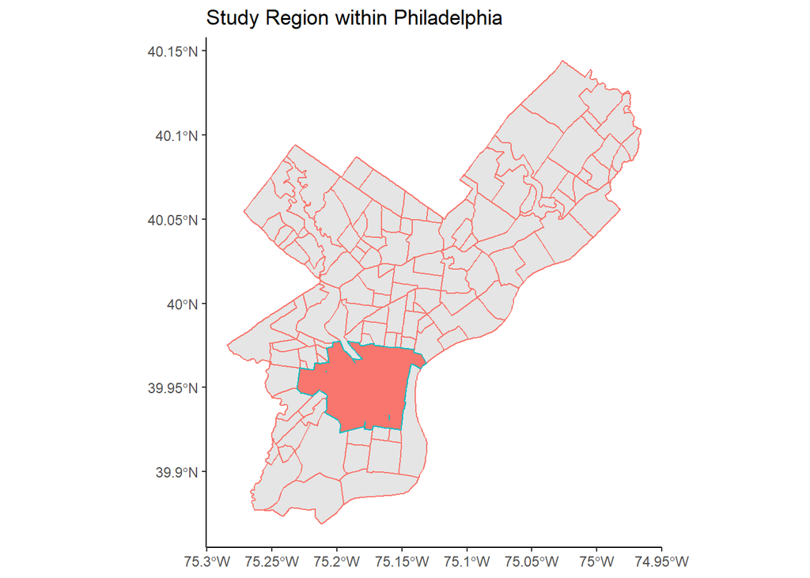

```r
ggplot() +
  geom_sf(data = full_boundary, aes(colour = "#FFFFFF"))+
  geom_sf(data = phil_boundary, aes(colour = "black", fill = "shape_area"))+
  labs(title = "Study Region within Philadelphia")+
  theme_classic() + theme(legend.position = "none")
```

```r
trip2 <- stations %>%
  mutate(interval60 = floor_date(mdy_hm(start_time), unit = "hour"),
         interval15 = floor_date(mdy_hm(start_time), unit = "15 mins"),
         week = week(interval60),
         dotw = wday(interval60, label=TRUE))
#glimpse(stations)

trip2 <-
  trip2  %>% st_transform("ESRI:102729")
```

# Importing Weather Data

```r
weather.Panel <-
  riem_measures(station = "PHL", date_start = "2019-10-01", date_end = "2020-01-01") %>%
  dplyr::select(valid, tmpf, p01i, sknt)%>%
  replace(is.na(.), 0) %>%
    mutate(interval60 = ymd_h(substr(valid,1,13))) %>%
    mutate(week = week(interval60),
           dotw = wday(interval60, label=TRUE)) %>%
    group_by(interval60) %>%
    summarize(Temperature = max(tmpf),
              Precipitation = sum(p01i),
              Wind_Speed = max(sknt)) %>%
    mutate(Temperature = ifelse(Temperature == 0, 42, Temperature))
```

# Bike share trips per Hr Philadlphia

Note the effect of weather on ride share in Philadelphia. As the temperatures lower throughout the winter, ride share usage drastically decreases.

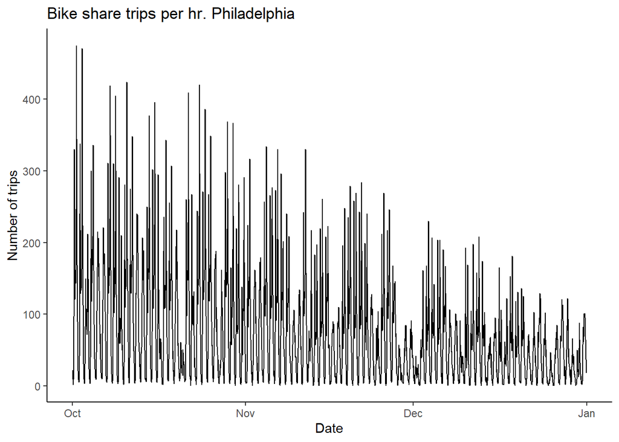

```r
ggplot(trip2 %>%
         group_by(interval60) %>%
         tally())+
  geom_line(aes(x = interval60, y = n))+
  labs(title="Bike share trips per hr. Philadelphia",
       x="Date",
       y="Number of trips")+
  theme_classic()
```

# Fishnet

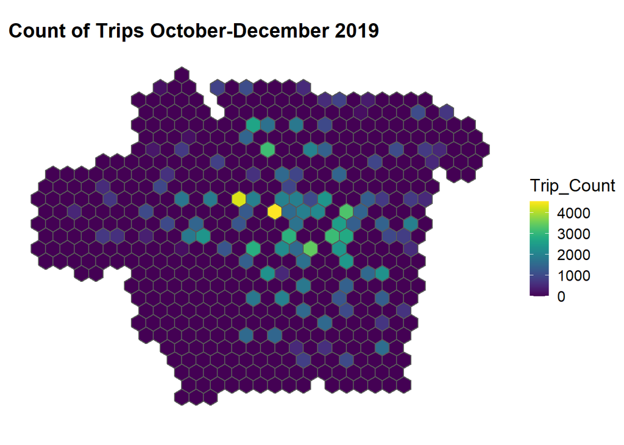

```r
fishnet <-
  st_make_grid(phil_boundary, cellsize = 900, square = FALSE) %>%
  .[phil_boundary] %>%
  st_sf()%>%
  mutate(uniqueID = rownames(.))


#bikenet
bikenet <-
  dplyr::select(trip2) %>%
  mutate(Trip_Count = 1) %>%
  aggregate(., fishnet, sum) %>%
  mutate(Trip_Count = replace_na(Trip_Count, 0),
         uniqueID = rownames(.),
         cvID = sample(round(nrow(fishnet) / 24), size=nrow(fishnet), replace = TRUE))

ggplot() +
  geom_sf(data = bikenet, aes(fill = Trip_Count)) +
  scale_fill_viridis() +
  labs(title = "Count of Trips October-December 2019")+
  theme_map()
```

# Ride Panel

```r
bikenet2 <-
  st_intersection(trip2, bikenet)

ride.panel <-
  bikenet2 %>%
    mutate(Trip_Counter = 1) %>%
      group_by(interval60, uniqueID) %>%
      summarize(Trip_Count = sum(Trip_Counter, na.rm=T)) %>%
      left_join(weather.Panel, by = "interval60") %>%
          mutate(week = week(interval60),
                dotw = wday(interval60, label = TRUE)) %>%
          st_sf()
```

# More Engineered Features — Training and Testing sets.

Training set was designated for weeks 41-43 in October, while the testing set was designated for weeks 44-45 Features engineered include proximity to bike lanes, parks and septa lines. Features were also engineered to maximize weekday and rush hour times.

```r
# ride.panel <-
#   ride.panel%>%
#   mutate(distbike = round(st_distance(ride.panel, bikepath))*100, 2)

septa <- st_read("https://opendata.arcgis.com/datasets/8c6e2575c8ad46eb887e6bb35825e1a6_0.geojson")%>%
  st_transform("ESRI:102729")
tree <- st_read("https://phl.carto.com/api/v2/sql?q=SELECT+*+FROM+ppr_tree_canopy_points_2015&filename=ppr_tree_canopy_points_2015&format=geojson&skipfields=cartodb_id")%>%
   st_transform("ESRI:102729")
bike_lanes <- st_read("C:/Users/Kyle McCarthy/Documents/MUSA_PubPolicy/bikelane/bikepathspts_clip.shp")
```

[figure not shown]

```r
st_c <- st_coordinates

ride.panel <-
  ride.panel %>%
    arrange(uniqueID, interval60) %>%
    group_by(uniqueID) %>%
    mutate(lagHour = dplyr::lag(Trip_Count,1),
           lag2Hours = dplyr::lag(Trip_Count,2),
           lag3Hours = dplyr::lag(Trip_Count,3),
           lag4Hours = dplyr::lag(Trip_Count,4),
           lag12Hours = dplyr::lag(Trip_Count,12),
           lag1day = dplyr::lag(Trip_Count,24)) %>%
   ungroup()%>%
  na.omit()

ride.panel <-
  ride.panel %>%
  mutate(
    bike_nn1 = nn_function(st_c(st_centroid(ride.panel)), st_c(bike_lanes), 1),
    bike_nn2 = nn_function(st_c(st_centroid(ride.panel)), st_c(bike_lanes), 2),
    bike_nn3 = nn_function(st_c(st_centroid(ride.panel)), st_c(bike_lanes), 3),
    bike_nn4 = nn_function(st_c(st_centroid(ride.panel)), st_c(bike_lanes), 4),
    bike_nn5 = nn_function(st_c(st_centroid(ride.panel)), st_c(bike_lanes), 5))

ride.panel <-
  ride.panel %>%
  mutate(
    septa_nn1 = nn_function(st_c(st_centroid(ride.panel)), st_c(septa), 1),
    septa_nn2 = nn_function(st_c(st_centroid(ride.panel)), st_c(septa), 2),
    septa_nn3 = nn_function(st_c(st_centroid(ride.panel)), st_c(septa), 3),
    septa_nn4 = nn_function(st_c(st_centroid(ride.panel)), st_c(septa), 4),
    septa_nn5 = nn_function(st_c(st_centroid(ride.panel)), st_c(septa), 5))

ride.panel <-
  ride.panel %>%
  mutate(
    tree_nn20 = nn_function(st_c(st_centroid(ride.panel)), st_c(tree), 20),
    tree_nn40 = nn_function(st_c(st_centroid(ride.panel)), st_c(tree), 40),
    tree_nn60 = nn_function(st_c(st_centroid(ride.panel)), st_c(tree), 60),
    tree_nn80 = nn_function(st_c(st_centroid(ride.panel)), st_c(tree), 80),
    tree_nn100 = nn_function(st_c(st_centroid(ride.panel)), st_c(tree), 100))

ride.Train <- filter(ride.panel, week == 41 | week == 42 | week == 43)
ride.Test <- filter(ride.panel, week == 44 | week == 45)


st_drop_geometry(rbind(
  mutate(ride.Train, Legend = "Training"),
  mutate(ride.Test, Legend = "Testing"))) %>%
    group_by(Legend, interval60) %>%
      summarize(Trip_Count = sum(Trip_Count)) %>%
      ungroup() %>%
      ggplot(aes(interval60, Trip_Count, colour = Legend)) + geom_line() +
        scale_colour_manual(values = palette2) +
        labs(title="Rideshare trips by week: November-December",
             x="Day", y="Trip Count")
```

# Exploratory Analysis Depicting the Correlation of Model Variables

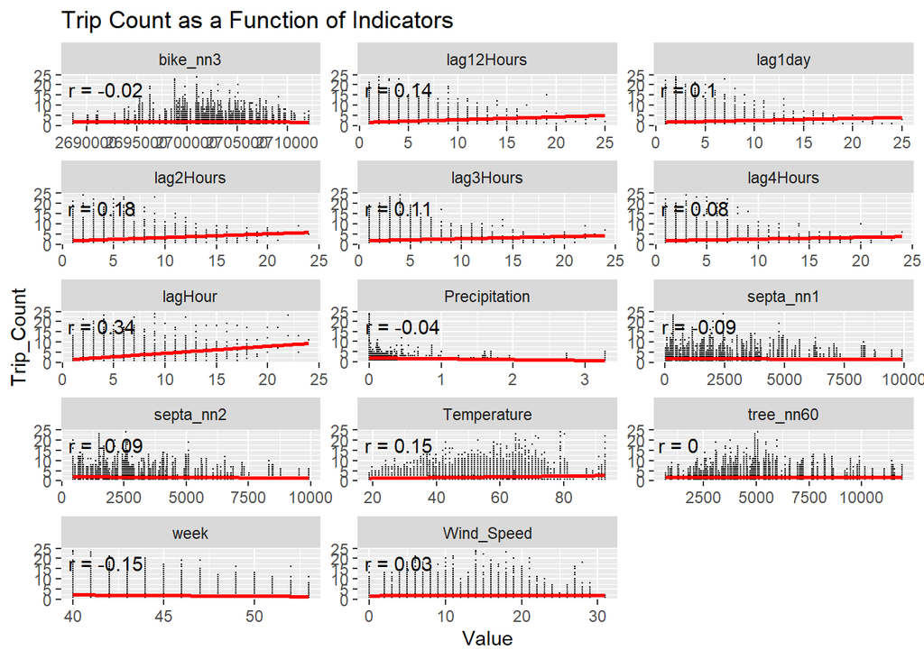

```r
ride.panel.na <-
  ride.panel%>%
  na.omit()

correlation.long <-
  st_drop_geometry(ride.panel.na) %>%
    dplyr::select(-dotw, - interval60, -uniqueID, - septa_nn3, - septa_nn4, -septa_nn5, -tree_nn20, -tree_nn40, -tree_nn80, -tree_nn100, -bike_nn1, -bike_nn2, -bike_nn4, -bike_nn5) %>%
    gather(Variable, Value, -Trip_Count)

correlation.long$Value <- as.double(correlation.long$Value )


correlation.cor <-
  correlation.long %>%
    group_by(Variable) %>%
    summarize(correlation = cor(Value, Trip_Count, use = "complete.obs"))

ggplot(correlation.long, aes(Value, Trip_Count)) +
  geom_point(size = 0.1) +
  geom_text(data = correlation.cor, aes(label = paste("r =", round(correlation, 2))),
            x=-Inf, y=Inf, vjust = 1.5, hjust = -.1) +
  geom_smooth(method = "lm", se = FALSE, colour = "red") +
  facet_wrap(~Variable, ncol = 3, scales = "free") +
  labs(title = "Trip Count as a Function of Indicators") +
  theme()
```

# Moran’s I anaysis.

The Moran I analysis was performed. To perform this analysis, a random subset of the data was taken for processing time (my computer was unable to load the full result). The output creats a trip_count map, a local moran I count, significant hotspots and p-value. Note that spatial autocorrelation exsists within the data, indicated by difference in the polygon’s center and at the edges.

[figure not shown]

```r
bikenet <-
  dplyr::select(trip2) %>%
  mutate(Trip_Count = 1) %>%
  aggregate(., fishnet, sum) %>%
  mutate(Trip_Count = replace_na(Trip_Count, 0),
         uniqueID = rownames(.),
         cvID = sample(round(nrow(fishnet) / 24), size=nrow(fishnet), replace = TRUE))

ride.panel <- ride.panel %>%
  st_transform("ESRI:102729")%>%
  filter(week == 41 | week == 42 | week == 43 | week == 44 | week == 45)

bikenet <-
  st_join(bikenet, ride.panel)%>%
  filter(week == 41 | week == 42 | week == 43 | week == 44 | week == 45)


bikenetsample <- sample_n(bikenet, 10000)%>%
  na.omit()

bikenetsample.nb <- poly2nb(as_Spatial(bikenetsample), queen=TRUE)
bikenetsample.weights <- nb2listw(bikenetsample.nb, style="W", zero.policy=TRUE)

bikenetsample.localMorans <-
  cbind(
    as.data.frame(localmoran(bikenetsample$Trip_Count.x, bikenetsample.weights)),
    as.data.frame(bikenetsample)) %>%
    st_sf() %>%
      dplyr::select(Trip_Count = Trip_Count.x,
                    Local_Morans_I = Ii,
                    P_Value = `Pr(z > 0)`) %>%
      mutate(Significant_Hotspots = ifelse(P_Value <= 0.05, 1, 0)) %>%
      gather(Variable, Value, -geometry)

vars <- unique(bikenetsample.localMorans$Variable)
varList <- list()

for(i in vars){
  varList[[i]] <-
    ggplot() +
    geom_sf(data = phil_boundary)+
      geom_sf(data = filter(bikenetsample.localMorans, Variable == i),
              aes(fill = Value), colour=NA) +
      scale_fill_viridis(name="") +
      labs(title=i) +
      theme_map() + theme(legend.position="right")}

do.call(grid.arrange,c(varList, ncol = 2, top = "Local Morans I statistics, Indego Counts from a Random sample "))
```

# Animation

The animation displayed below depicts bike share usage on Octorber 8th, 2019. There are distinct rises in bike share uses throughout the day as depicted by the red points on the map. Higher ride share usages correspond with rush hour times. Note that this date was a Tuesday during the week.

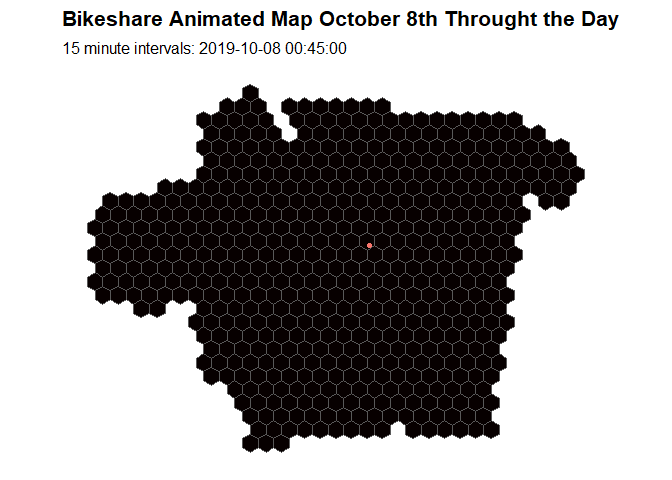

```r
week45 <-
  filter(bikenet2, week == 41 | week == 42 | week == 43 | week == 44 | week == 45)
week45 <- sample_n(week45, 5000)

week45.panel <-
  expand.grid(
    interval15 = unique(week45$interval15),
    uniqueID = unique(bikenet2$uniqueID))%>%
  na.omit()

week45.panel <- sample_n(week45.panel, 5000)


ride.animation.data <-
  mutate(week45, Trip_Counter = 1) %>%
    group_by(interval15, uniqueID) %>%
    summarize(Trip_Count = sum(Trip_Counter, na.rm=T)) %>%
    ungroup() %>%
    st_join(bikenetsample, by=c("uniqueID" = "uniqueID.x")) %>%
    st_sf() %>%
    mutate(Trips = case_when(Trip_Count == 0 ~ "0 trips",
                             Trip_Count > 0 & Trip_Count <= 3 ~ "1-3 trips",
                             Trip_Count > 3 & Trip_Count <= 6 ~ "4-6 trips",
                             Trip_Count > 6 & Trip_Count <= 10 ~ "7-10 trips",
                             Trip_Count > 10 ~ "11+ trips")) %>%
    mutate(Trips  = fct_relevel(Trips, "0 trips","1-3 trips","4-6 trips",
                                       "7-10 trips","10+ trips"))


ride.animation.data <-
  ride.animation.data%>%
  mutate(day = day(interval15))
ride.animation.data <-
  ride.animation.data%>%
  filter(week == 41 & day == 8)

ride.animation.data <- sample_n(ride.animation.data, 1000)



rideshare_animation <-
   ggplot() +
  geom_sf(data = phil_boundary)+
  geom_sf(data = fishnet, fill = "#070000")+
     geom_sf(data = ride.animation.data, aes(fill = Trips, colour = "#F7FA15")) +
     scale_fill_manual(values = palette5) +
     labs(title = "Bikeshare Animated Map October 8th Throught the Day",
          subtitle = "15 minute intervals: {current_frame}") +
     transition_manual(interval15) +
     theme_map()+ theme(legend.position = "none")

 animate(rideshare_animation, duration=20, renderer = gifski_renderer())
```

```r
 anim_save("rideshare_local", rideshare_animation, duration=20, renderer = gifski_renderer())
```

# Rain Vs. Snow

Precipitation decreases bike share usage as depicted in the bar chart.

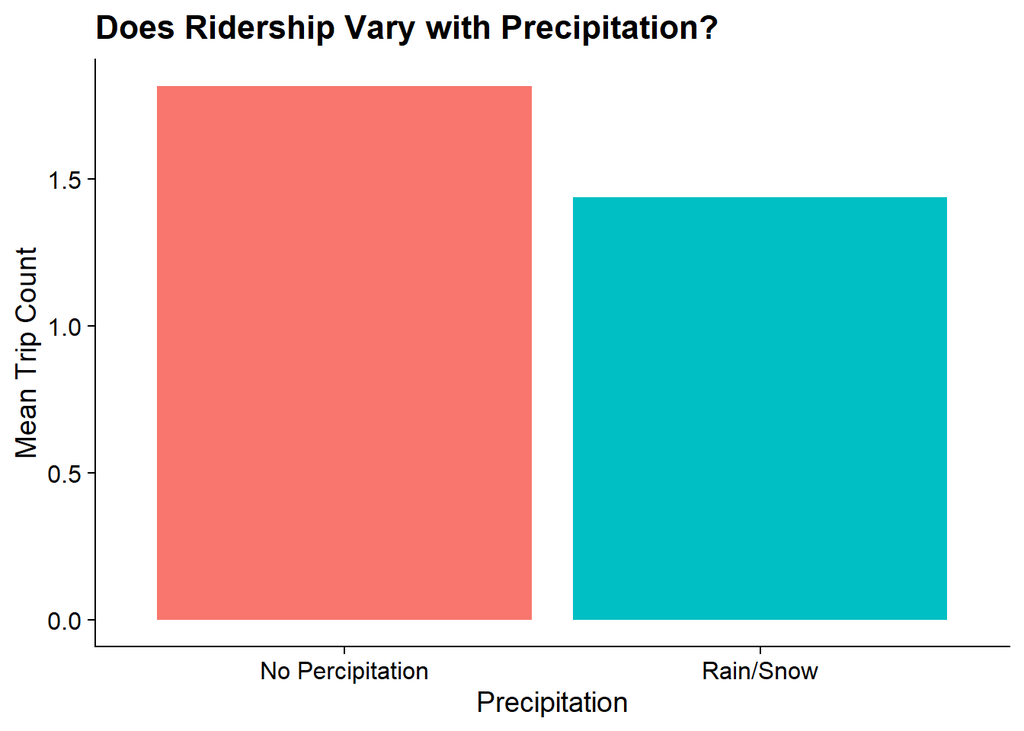

```r
st_drop_geometry(ride.panel) %>%
  group_by(interval60) %>%
  summarize(Trip_Count = mean(Trip_Count),
            Precipitation = first(Precipitation)) %>%
  mutate(isPrecip = ifelse(Precipitation > 0,"Rain/Snow", "No Percipitation")) %>%
  group_by(isPrecip) %>%
  summarize(Mean_Trip_Count = mean(Trip_Count)) %>%
    ggplot(aes(isPrecip, Mean_Trip_Count, fill = isPrecip)) + geom_bar(stat = "identity") +
      labs(title="Does Ridership Vary with Precipitation?",
           x="Precipitation", y="Mean Trip Count") + theme_cowplot()+ theme(legend.position = "NONE")
```

# Temparature vs. Trip Count

Typically, as temperature increases, bike share increases. However, the amount that temperature plays a role seems to vary week from week.

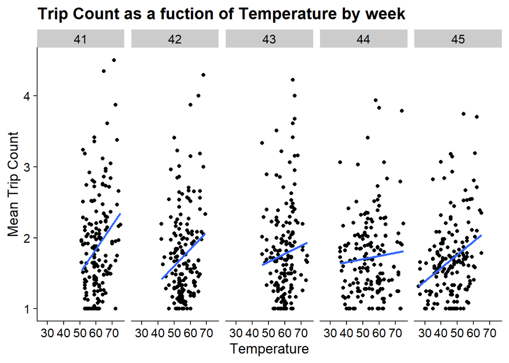

```r
st_drop_geometry(ride.panel) %>%
  group_by(interval60) %>%
  summarize(Trip_Count = mean(Trip_Count),
            Temperature = first(Temperature)) %>%
  mutate(week = week(interval60)) %>%
  ggplot(aes(Temperature, Trip_Count)) +
    geom_point() + geom_smooth(method = "lm", se= FALSE) +
    facet_wrap(~week, ncol=7) +
    labs(title="Trip Count as a fuction of Temperature by week",
         x="Temperature", y="Mean Trip Count") + theme()+ theme_cowplot()
```

# Regressions

```r
reg1 <- lm(Trip_Count ~  hour(interval60) + dotw + Temperature,  data=ride.Train)

reg2 <- lm(Trip_Count ~  uniqueID + dotw + Temperature,  data=ride.Train)

reg3 <- lm(Trip_Count ~  uniqueID + hour(interval60) + dotw + Temperature ,
                         data=ride.Train)

reg4 <- lm(Trip_Count ~  uniqueID +  hour(interval60) + dotw + Temperature +
                         lagHour + lag2Hours + lag3Hours + lag12Hours + lag1day,
                         data=ride.Train)

reg5 <- lm(Trip_Count ~  uniqueID +  hour(interval60) +  dotw + lagHour + lag2Hours + lag3Hours + lag12Hours + lag1day + septa_nn2 + Precipitation  + Wind_Speed + Temperature + tree_nn20 + bike_nn5,  data=ride.Train)
```

# Purr test

The purr family functions are utilized to loop through a set of nested data frames. to efficiently compare accross different spatial models. The five models in the regression above are compared using the purr functions. The nested loop loops through each model for each week and mutates the summary statistics. The output is a list of predictions for each model by week. These results are then gathered, generating four new collumns. To calculate MAE, map_dbl, a variant of map, is used to loop through Absolute_Error, calculating the mean. The same function calculates the standard deviation of absolute error, sd_AE, which is a useful measure of generalizability (Steif, 2020). The final result is depicted in the form of a histogram, comparing the week to Mean average error for weeks 44 and 45.

```r
ride.panel <-
  ride.panel %>%
    arrange(uniqueID, interval60) %>%
    group_by(uniqueID) %>%
    mutate(lagHour = dplyr::lag(Trip_Count,1),
           lag2Hours = dplyr::lag(Trip_Count,2),
           lag3Hours = dplyr::lag(Trip_Count,3),
           lag4Hours = dplyr::lag(Trip_Count,4),
           lag12Hours = dplyr::lag(Trip_Count,12),
           lag1day = dplyr::lag(Trip_Count,24)) %>%
   ungroup()%>%
  na.omit()

ride.Train <- filter(ride.panel, week == 41 | week == 42 | week == 43)
ride.Test <- filter(ride.panel, week == 44 | week == 45)


ride.Test.weekNest <-
  as.data.frame(ride.Test) %>%
  nest(-week)

ride.Test.weekNest
```

```
## # A tibble: 2 x 2
##    week data
##   <dbl> <list>
## 1    44 <tibble [6,789 x 29]>
## 2    45 <tibble [6,781 x 29]>
```

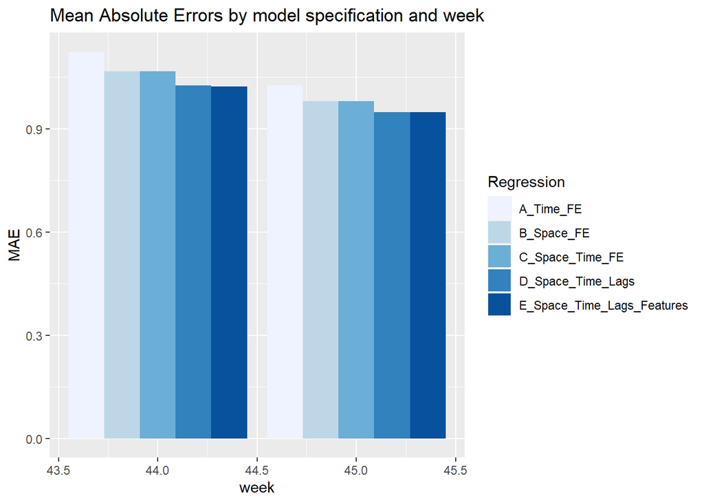

```r
model_pred <- function(dat, fit){
   pred <- predict(fit, newdata = dat)}

week_predictions <-
  ride.Test.weekNest %>%
    mutate(A_Time_FE = map(.x = data, fit = reg1, .f = model_pred),
           B_Space_FE = map(.x = data, fit = reg2, .f = model_pred),
           C_Space_Time_FE = map(.x = data, fit = reg3, .f = model_pred),
           D_Space_Time_Lags = map(.x = data, fit = reg4, .f = model_pred),
           E_Space_Time_Lags_Features =map(.x = data, fit = reg5, .f = model_pred))

week_predictions <- week_predictions %>%
    gather(Regression, Prediction, -data, -week) %>%
    mutate(Observed = map(data, pull, Trip_Count),
           Absolute_Error = map2(Observed, Prediction,  ~ abs(.x - .y)),
           MAE = map_dbl(Absolute_Error, mean),
           sd_AE = map_dbl(Absolute_Error, sd))

week_predictions %>%
  dplyr::select(week, Regression, MAE) %>%
  gather(Variable, MAE, -Regression, -week) %>%
  ggplot(aes(week, MAE)) +
    geom_bar(aes(fill = Regression), position = "dodge", stat="identity") +
    scale_fill_manual(values = palette5) +
    labs(title = "Mean Absolute Errors by model specification and week") + theme()
```

# Purr Prediction graph result

Below is a graph generating from the purr family functions, depicting the predicted value compared to the observed value by an hourly interval.

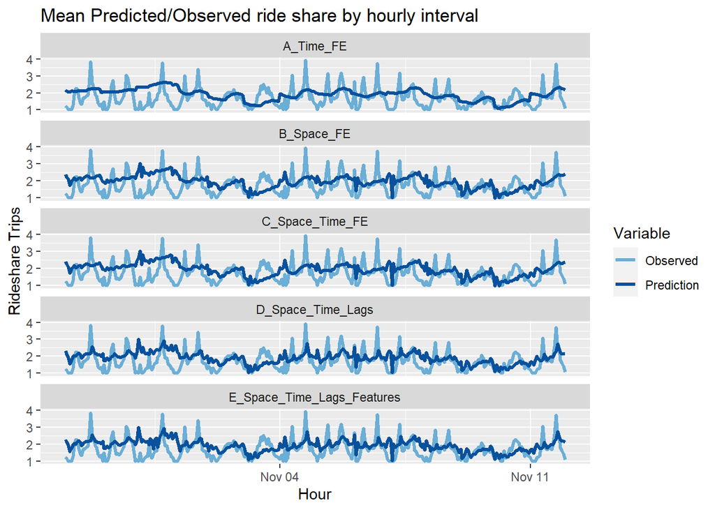

```r
week_predictions %>%
  mutate(interval60 = map(data, pull, interval60),
         uniqueID = map(data, pull, uniqueID)) %>%
  dplyr::select(interval60, uniqueID, Observed, Prediction, Regression) %>%
  unnest() %>%
  gather(Variable, Value, -Regression, -interval60, -uniqueID) %>%
    group_by(Regression, Variable, interval60) %>%
    summarize(Value = mean(Value)) %>%
    ggplot(aes(interval60, Value, colour=Variable)) + geom_line(size = 1.1) +
      facet_wrap(~Regression, ncol=1) +
      scale_colour_manual(values = palette2) +
      labs(title = "Mean Predicted/Observed ride share by hourly interval",
           x = "Hour", y= "Rideshare Trips") + theme()
```

# Purr Map Results

Depicted below is a map if the mean average error, depicting spatially where mean average error is the highest. Displayed here, the mean average error is higheest towards the center (which tends to be more populatied. Consequently, the regression model can be further improved by accounting for these high population density spatial regions.

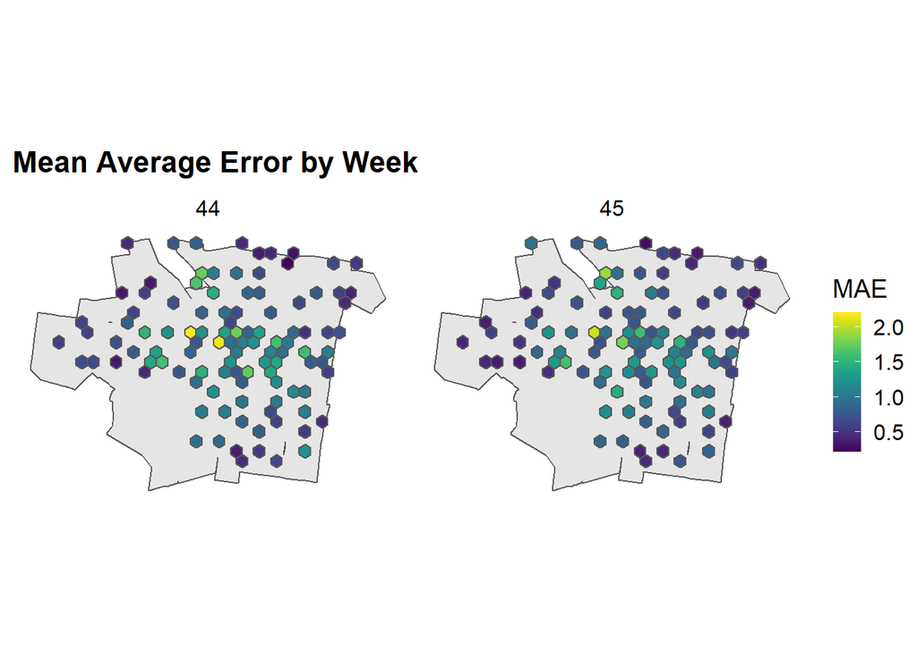

```r
error.byWeek <-
  filter(week_predictions, Regression == "D_Space_Time_Lags") %>%
  unnest() %>% st_sf() %>%
  dplyr::select(uniqueID, Absolute_Error, week, geometry) %>%
  gather(Variable, Value, -uniqueID, -week, -geometry) %>%
    group_by(Variable, uniqueID, week) %>%
    summarize(MAE = mean(Value))

fishnet1<-
  st_join(fishnet, error.byWeek)%>%
  na.omit()

error.byWeek <-
  error.byWeek%>%
  na.omit()

  ggplot() +
  geom_sf(data = phil_boundary) +
  geom_sf(data = fishnet1, aes(fill = MAE))+
  facet_wrap(~week) +
  scale_fill_viridis() +
  labs(title = "Mean Average Error by Week")+
  theme_map()
```

# Cross Validation

[output not shown]

[output cut: 52 more lines]

[output not shown]

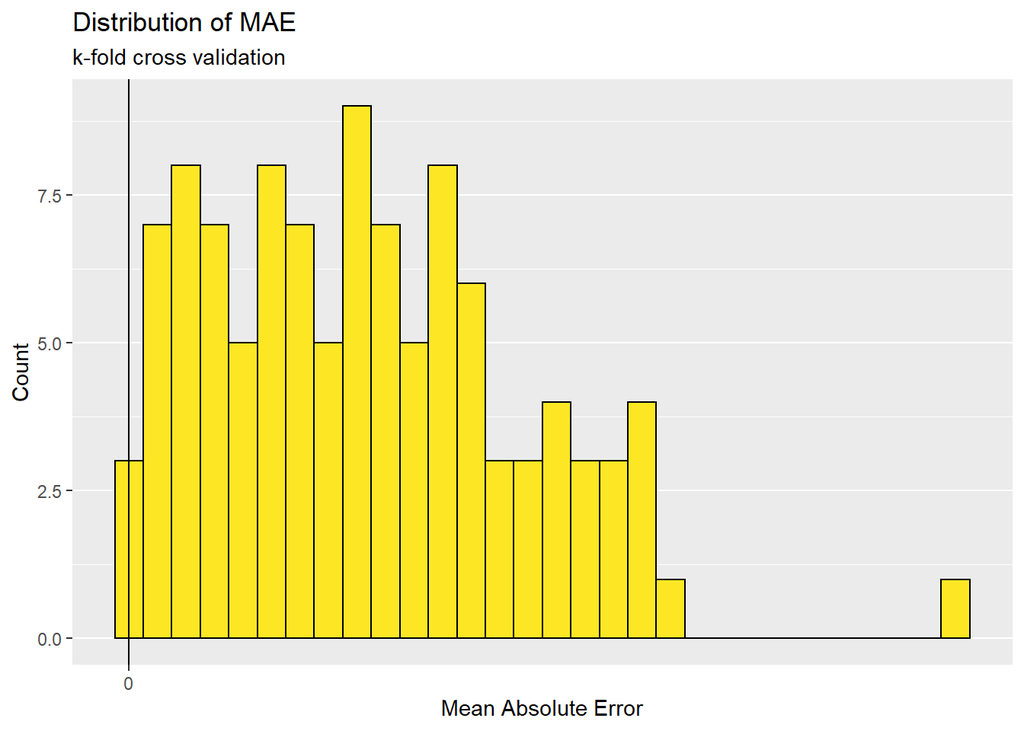

# K- Fold Regression Map.

Note that higher error is associated with Philadelphia’s Central Business District.

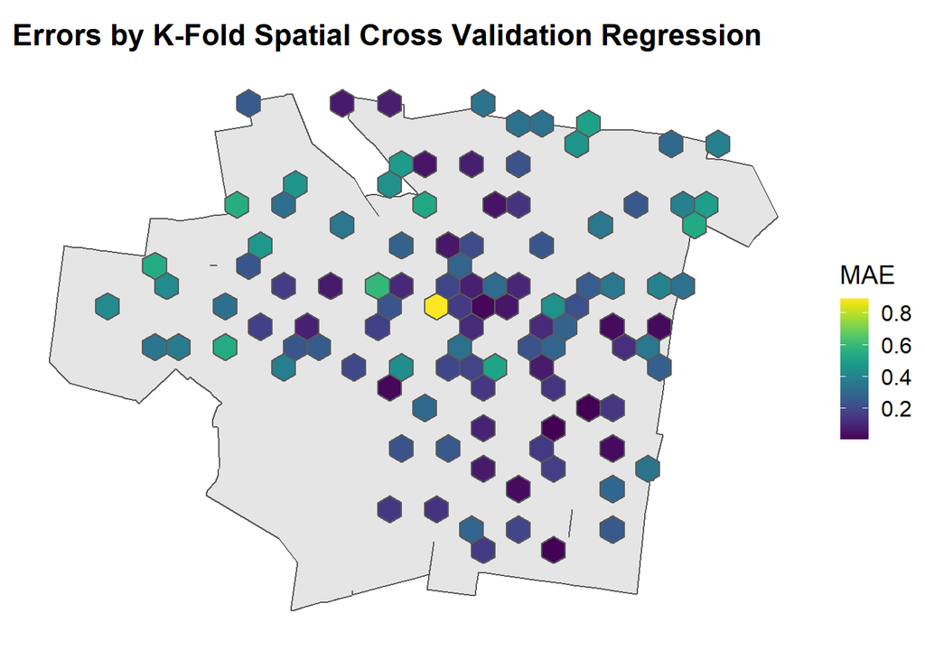

```r
fishnet2<-
  st_join(fishnet, error_by_reg_and_fold)%>%
  na.omit()



fishnet2 %>%
  ggplot() +
  geom_sf(data = phil_boundary)+
    geom_sf(aes(fill = MAE)) +
    scale_fill_viridis() +
    labs(title = "Errors by K-Fold Spatial Cross Validation Regression") +
    theme_map() + theme(legend.position="right")
```

# K Fold Regression Table

```r
st_drop_geometry(error_by_reg_and_fold) %>%
  group_by(Regression) %>%
    summarize(Mean_MAE = round(mean(MAE), 2),
              SD_MAE = round(sd(MAE), 2)) %>%
  kable() %>%
    kable_styling("striped", full_width = F) %>%
    row_spec(1, color = "black", background = "#64E4F4")
```

| Regression | Mean_MAE | SD_MAE |
| --- | --- | --- |
| Random k-fold CV: Spatial Process | 0.25 | 0.17 |

# Conclusion

[output not shown]